# Exploratory Data Analysis

Raymond Wong

16/05/2020

```r
# Import tidyverse, read the data into a csv

library(tidyverse)

raw_data <- read_csv("grocery_store_data_cleaned.csv")
```

```r
# Check the structure of the data
str(raw_data)
```

```
## tibble [659,221 x 16] (S3: spec_tbl_df/tbl_df/tbl/data.frame)
##  $ X1               : num [1:659221] 0 1 2 3 4 5 6 7 8 9 ...
##  $ TICKET           : chr [1:659221] "d9ea23a9-8a1b-41b4-b554-2bf7e96ca2d9" "d9ea23a9-8a1b-41b4-b554-2bf7e96ca2d9" "f4dd518d-1fd8-4339-abc6-2c5390c20e30" "aa299de6-1332-48ba-bce9-de8cbb48741e" ...
##  $ UNITS            : num [1:659221] 3.29 0.29 -1 3.29 1 ...
##  $ REFERENCE        : num [1:659221] 1079 2032 2032 1001 4019 ...
##  $ CODE             : num [1:659221] 1.08e+03 2.03e+03 2.03e+03 1.00e+03 8.89e+12 ...
##  $ NAME             : chr [1:659221] "Pumpkin Japanese/Kent" "Orange navel" "Orange navel" "Australian Asparagus green" ...
##  $ UNIT_PRICEBUY    : num [1:659221] 0 0 0 2 0.9 2 0 2 0 0 ...
##  $ UNIT_PRICESELL   : num [1:659221] 1.99 2.99 2.99 2.7 1.5 ...
##  $ DATE             : POSIXct[1:659221], format: "2016-03-16 23:15:39" "2016-03-16 23:15:39" ...
##  $ PAYMENT          : chr [1:659221] "cash" "cash" "cashrefund" "cash" ...
##  $ TRANSID          : chr [1:659221] "no ID" "no ID" NA "no ID" ...
##  $ CATEGORY         : chr [1:659221] "Pumpkins" "Citrus" "Citrus" "Bunch Vegies" ...
##  $ TOTAL_PRICEBUY   : num [1:659221] 0 0 0 6.58 0.9 ...
##  $ TOTAL_PRICESELL  : num [1:659221] 6.551 0.867 -2.99 8.888 1.5 ...
##  $ UNIT_PRICE_MARGIN: num [1:659221] 1.99 2.99 2.99 0.7 0.6 ...
##  $ PROFIT           : num [1:659221] 6.551 0.867 -2.99 2.304 0.6 ...
##  - attr(*, "spec")=
##   .. cols(
##   ..   X1 = col_double(),
##   ..   TICKET = col_character(),
##   ..   UNITS = col_double(),
##   ..   REFERENCE = col_double(),
##   ..   CODE = col_double(),
##   ..   NAME = col_character(),
##   ..   UNIT_PRICEBUY = col_double(),
##   ..   UNIT_PRICESELL = col_double(),
##   ..   DATE = col_datetime(format = ""),
##   ..   PAYMENT = col_character(),
##   ..   TRANSID = col_character(),
##   ..   CATEGORY = col_character(),
##   ..   TOTAL_PRICEBUY = col_double(),
##   ..   TOTAL_PRICESELL = col_double(),
##   ..   UNIT_PRICE_MARGIN = col_double(),
##   ..   PROFIT = col_double()
##   .. )
```

```r
# Get summary of data

summary(raw_data)
```

```
##        X1            TICKET              UNITS           REFERENCE
##  Min.   :     0   Length:659221      Min.   :-1.0000   Min.   :1001
##  1st Qu.:164805   Class :character   1st Qu.: 0.4540   1st Qu.:1067
##  Median :329610   Mode  :character   Median : 1.0000   Median :1205
##  Mean   :329610                      Mean   : 0.9043   Mean   :2134
##  3rd Qu.:494415                      3rd Qu.: 1.0000   3rd Qu.:2059
##  Max.   :659220                      Max.   :48.0000   Max.   :9998
##       CODE               NAME           UNIT_PRICEBUY    UNIT_PRICESELL
##  Min.   :1.001e+03   Length:659221      Min.   : 0.000   Min.   : 0.000
##  1st Qu.:1.067e+03   Class :character   1st Qu.: 0.000   1st Qu.: 2.000
##  Median :1.256e+03   Mode  :character   Median : 0.000   Median : 2.990
##  Mean   :3.825e+13                      Mean   : 1.116   Mean   : 3.973
##  3rd Qu.:2.070e+03                      3rd Qu.: 2.000   3rd Qu.: 4.900
##  Max.   :9.189e+16                      Max.   :45.000   Max.   :53.000
##       DATE                       PAYMENT            TRANSID
##  Min.   :2016-03-16 23:15:39   Length:659221      Length:659221
##  1st Qu.:2017-01-15 02:48:03   Class :character   Class :character
##  Median :2017-11-16 12:07:41   Mode  :character   Mode  :character
##  Mean   :2017-11-30 17:03:10
##  3rd Qu.:2018-10-13 09:31:51
##  Max.   :2019-10-13 17:43:20
##    CATEGORY         TOTAL_PRICEBUY     TOTAL_PRICESELL   UNIT_PRICE_MARGIN
##  Length:659221      Min.   : -2.0000   Min.   : -2.990   Min.   :-20.000
##  Class :character   1st Qu.:  0.0000   1st Qu.:  1.500   1st Qu.:  0.990
##  Mode  :character   Median :  0.0000   Median :  2.315   Median :  2.000
##                     Mean   :  0.9997   Mean   :  2.887   Mean   :  2.857
##                     3rd Qu.:  1.5760   3rd Qu.:  3.500   3rd Qu.:  3.500
##                     Max.   :138.0000   Max.   :230.000   Max.   : 25.000
##      PROFIT
##  Min.   :-22.837
##  1st Qu.:  0.700
##  Median :  1.420
##  Mean   :  1.887
##  3rd Qu.:  2.500
##  Max.   :215.000
```

```r
# Check the categories for each variable, find how many unique entries, helps us figure out what the variables mean, which are categorical, etc.

unique_entries <- apply(raw_data, 2, unique)

num_unique <- sapply(unique_entries, length)

(num_unique)
```

```
##                X1            TICKET             UNITS         REFERENCE
##            659221            181970              3437              1265
##              CODE              NAME     UNIT_PRICEBUY    UNIT_PRICESELL
##               619              1266               230               196
##              DATE           PAYMENT           TRANSID          CATEGORY
##            181969                 4             32428                43
##    TOTAL_PRICEBUY   TOTAL_PRICESELL UNIT_PRICE_MARGIN            PROFIT
##              9758             21239               279             30201
```

Each row of data corresponds to one item being sold with the following attributes of the purchase recorded.

**X1**: irrelevant

**TICKET**: Character, the unique ID of each transaction (i.e. receipt number), several rows can have same ticket, as it just means several items were bought in one transaction

**UNITS**: Numeric, quantity of the item transacted with (could be in kg, lbs, bags, etc.)

**REFERENCE**: Numeric, unique code assigned to each item

**CODE**: Not sure, but never used

**NAME**: character, name of the item purchased

**UNIT_PRICEBUY**: Numeric, cost to the grocery store of one unit of the item being purchased

**UNIT_PRICESELL**: Numeric, how much one unit of the item being purchased was sold for

**PAYMENT**: Character, choics are cash, cashrefund, magcard or free, indiciating how the customer paid for the item

**TRANSID**: Not sure, but never used

**CATEGORY**: Character, The larger group of which the item purchased belongs to

**TOTAL_PRICEBUY**: Numeric, where $\text{TOTAL_PRICEBUY}= \text{UNITS} * \text{UNIT_PRICEBUY}$, is the cost of the purchase to the grocery store (e.g. costs from purchasing the good to inventory, etc.)

**TOTAL_PRICESELL**: Numeric, where $\text{TOTAL_PRICESELL} = \text{UNITS} * \text{UNIT_PRICESELL}$, is the sale value of the purchase

**UNIT_PRICE_MARGIN**: Numeric, where $\text{UNIT_PRICE_MARGIN}= \text{UNIT_PRICESELL} - \text{UNIT_PRICEBUY}$, profit per unit sold of that purchase

**PROFIT**: Numeric, where $\text{PROFIT} = \text{TOTAL_PRICESELL} - \text{TOTAL_PRICEBUY}$, total profit of that purchase

### Analyzing the Margins by Category

We want to see which categories are highest margin, as we would want to sell more high margin products and sell less low margin products so we can make more money.

```r
data <- raw_data %>% mutate(margin_percent = UNIT_PRICE_MARGIN/UNIT_PRICESELL)

# Check for number of products with "100% margin", those are probably wrong

data <- data %>% mutate(pure_profit = ifelse(abs(margin_percent - 1) < .Machine$double.eps, 1, 0))

# Group by category

by_category <- data %>% group_by(CATEGORY)

by_category_summary <- by_category %>% summarise(
  total_units = sum(UNITS, na.rm = TRUE),
  total_profit = sum(PROFIT, na.rm = TRUE),
  average_margin_percent = mean(margin_percent, na.rm = TRUE),
  median_margin_percent = median(margin_percent),
  sd_margin_percent = sd(margin_percent, na.rm = TRUE),
  avg_unit_price_sell = mean(UNIT_PRICESELL, na.rm = TRUE),
  sd_unit_price_sell = sd(UNIT_PRICESELL, na.rm = TRUE),
  num_pure_profit = sum(pure_profit, na.rm = TRUE),
  count = n()
)  %>% mutate(percent_pure_profit = num_pure_profit/count) %>%
  mutate(profit_per_unit = total_profit/count) %>%
  mutate(normalized_sd_price_sell_unit = sd_unit_price_sell/avg_unit_price_sell) %>%
  mutate(sharpe = 1/normalized_sd_price_sell_unit)
```

We notice some categories have abnormally high average margins for their items while others are quite low.

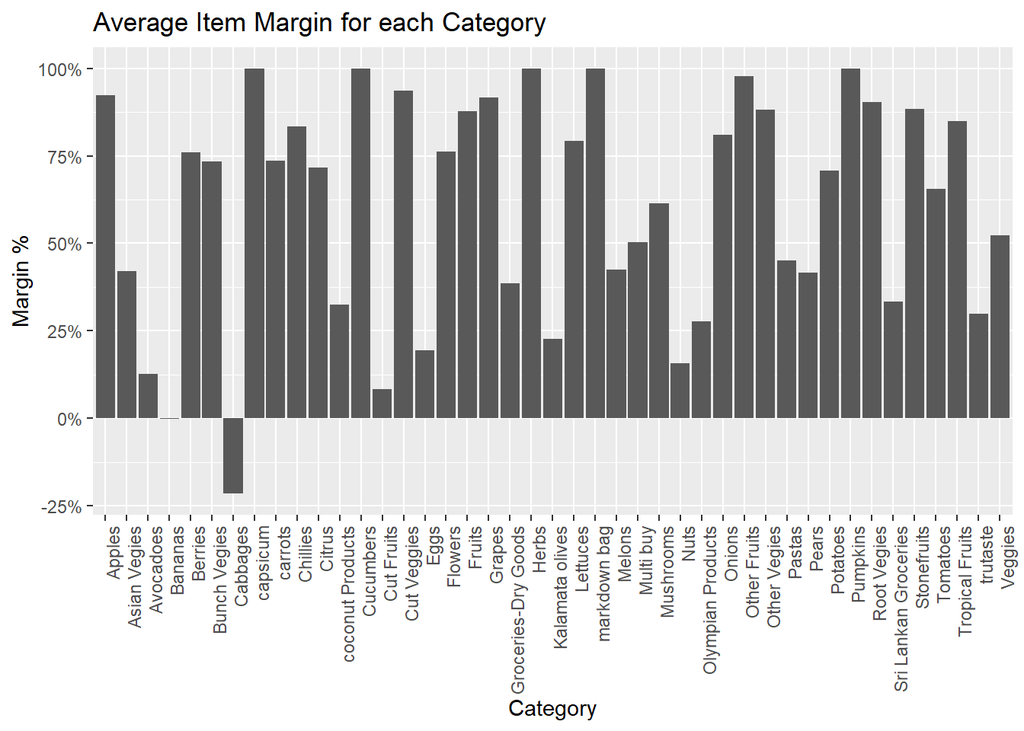

```r
library(scales)

ggplot(data = by_category_summary) +
  geom_bar(mapping = aes(x = CATEGORY, y = average_margin_percent), stat = "identity") + theme(axis.text.x = element_text(angle = 90, hjust = 1)) +
  ggtitle("Average Item Margin for each Category") +
  scale_y_continuous(name = "Margin %", labels = percent) +
  scale_x_discrete(name = "Category")
```

We can attribute these abnormally high margins to many of their UNIT_PRICEBUY attributes equalling 0, in other words their margin is 100%!

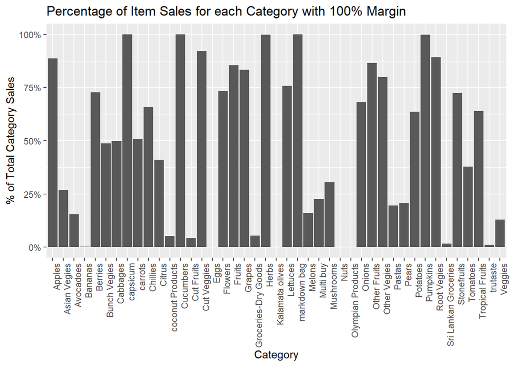

```r
ggplot(data = by_category_summary) +
  geom_bar(mapping = aes(x = CATEGORY, y = percent_pure_profit), stat = "identity") + theme(axis.text.x = element_text(angle = 90, hjust = 1)) +
  ggtitle("Percentage of Item Sales for each Category with 100% Margin") + scale_y_continuous(name = "% of Total Category Sales", labels = percent) +
  scale_x_discrete(name = "Category")
```

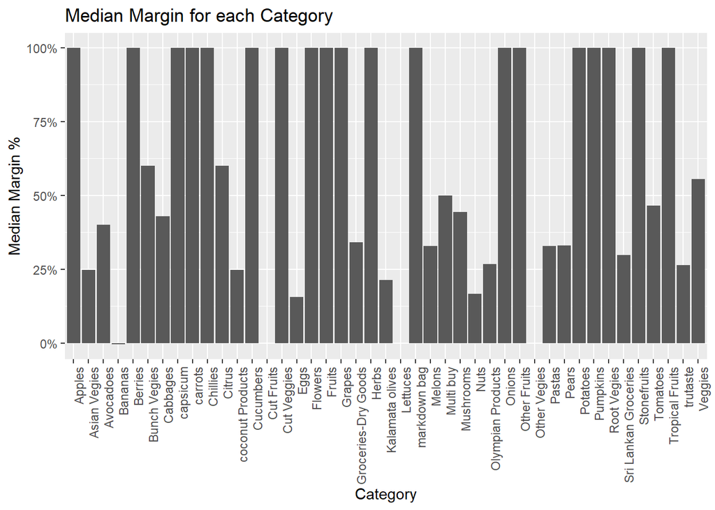

```r
ggplot(data = by_category_summary) +
  geom_bar(mapping = aes(x = CATEGORY, y = median_margin_percent), stat = "identity") + theme(axis.text.x = element_text(angle = 90, hjust = 1)) +
  ggtitle("Median Margin for each Category") +
  scale_y_continuous(name = "Median Margin %", label = percent) +
  scale_x_discrete(name = "Category")
```

This is likely an error, as that implies those items cost nothing to the grocery store to procure. Even if this is not an error, i.e. they were grown on the grocery store’s own farm and not bought from another supplier, it costs the grocery store money to grow food on the farm, which is a cost that should be reflected in UNIT_PRICEBUY. Therefore, it is inaccurate to say some items have 100% margin, as no item can be procured/grown without incurring any cost. However, we’ve seen that this error is quite pervasive, which unfortunately means we cannot use margins as a KPI anymore.